# Scater Plots with Base R functions

To plot two sets of points in R, you only need to supply the x and y points. For example, let’s define two vectors, x and y and plot them.

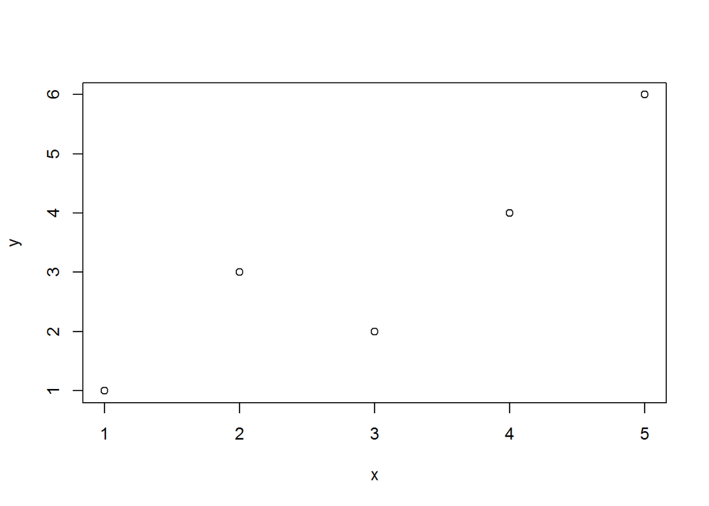

```r
x <- c(1,2,3,4,5)
y <- c(1,3,2,4,6)
plot(x,y)
```

Suppose we want to connect the points by lines. We can use the type argument in the plot function. Let’s also try to add a title and change the labels of the axes.

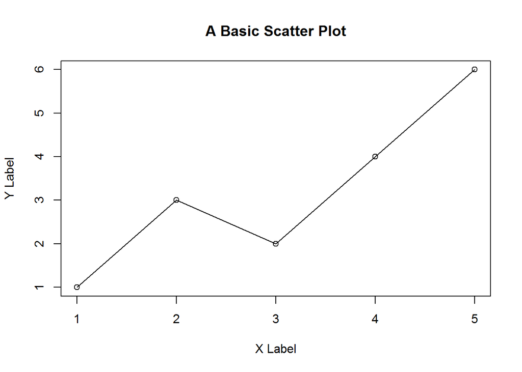

```r
plot(x,y, main='A Basic Scatter Plot', xlab='X Label',
      ylab='Y Label', type='o')
```

Let’s define another set of points to plot.

```r
x1 <- x
y1 <- y+1
```

Suppose we want to plot both the pairs on the respective axes. We have to make sure use the correct x and y ranges. We can distinguish the x1, y1 points from the x,y points by giving them different colors by using the col argument in both the plot and lines functions. We should probably also add a legend to help distinguish the points.

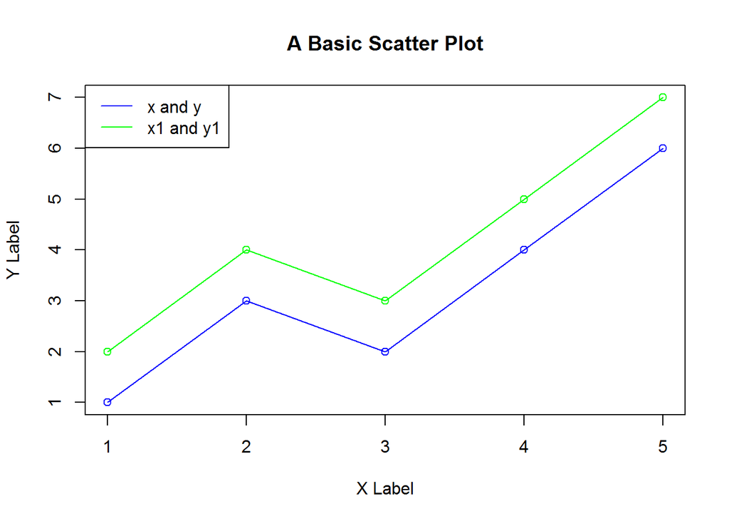

```r
plot(x,y, main='A Basic Scatter Plot',
     xlab='X Label', ylab='Y Label', type='o',
     xlim=range(c(x,x1)), ylim = range(c(y, y1)), col='blue')
lines(x1, y1, col='green', type='o')
legend(x='topleft', legend=c('x and y', 'x1 and y1'),
       col=c('blue', 'green'), lty=c(1,1))
```

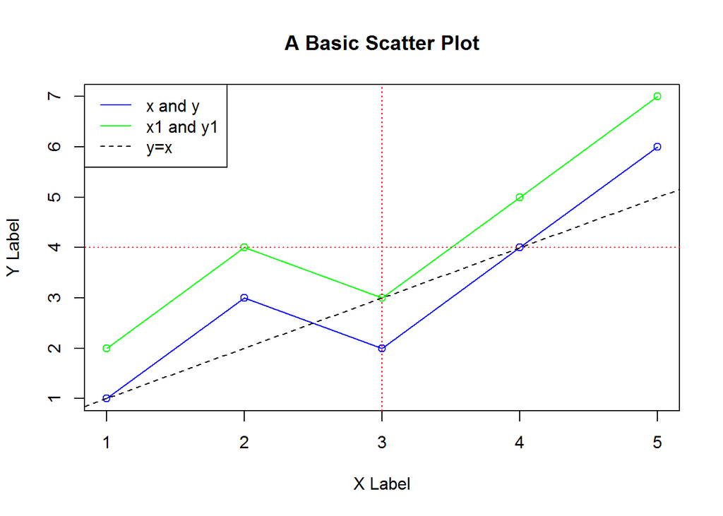

```r
plot(x,y, main='A Basic Scatter Plot',
       xlab='X Label', ylab='Y Label', type='o',
      xlim=range(c(x,x1)), ylim = range(c(y, y1)), col='blue')
lines(x1, y1, col='green', type='o')
abline(a=0, b=1, lty=2)
abline(v=3, col='red', lty=3) #v stands for vertical
abline(h=4, col='red', lty=3) #h stands for horizontal
legend(x='topleft', legend=c('x and y', 'x1 and y1', 'y=x'),
       col=c('blue', 'green', 'black'), lty=c(1,1,2))
```

Suppose we didn’t want the lines but points. The argument pch controls the different type of points we can use.

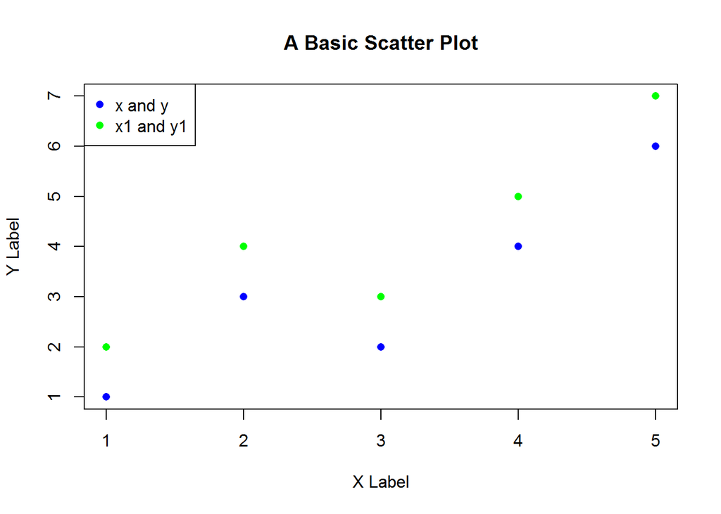

```r
plot(x,y, main='A Basic Scatter Plot',
      xlab='X Label', ylab='Y Label', type='p',
     ylim = range(c(y, y1)), col='blue', pch=16)#NOTE: 'p' in type is for points
points(x1, y1, col='green', pch=16)
legend(x='topleft', legend=c('x and y', 'x1 and y1'),
         col=c('blue', 'green'), pch=c(16,16) )
```

Suppose we wanted to add text instead of points. For example, suppose we want to label the x y points as ‘a’ and the x1 y1 points as ‘b’. We can change the plot type to ‘n’ then use the text functions.

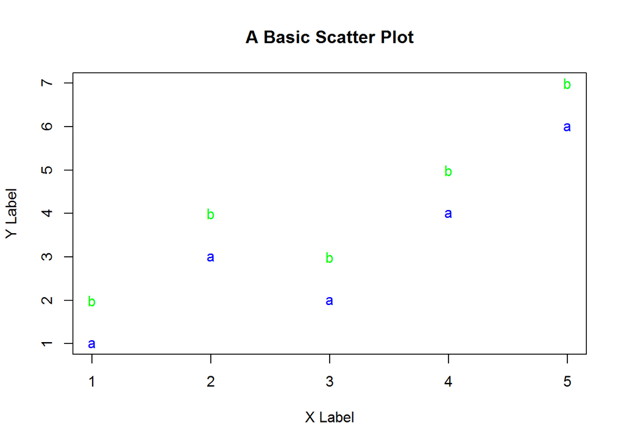

```r
plot(x,y, main='A Basic Scatter Plot',
       xlab='X Label', ylab='Y Label', type='n',
       xlim=range(c(x,x1)), ylim = range(c(y, y1)), col='blue', pch=16)
text(x,y, labels = 'a', col='blue')
text(x1,y1, labels = 'b', col='green')
```

Say we want to just plot x versus y, but we want a black background, white axes, a cyan main title and a green subtitle. We can use the par function to set graphical parameters.

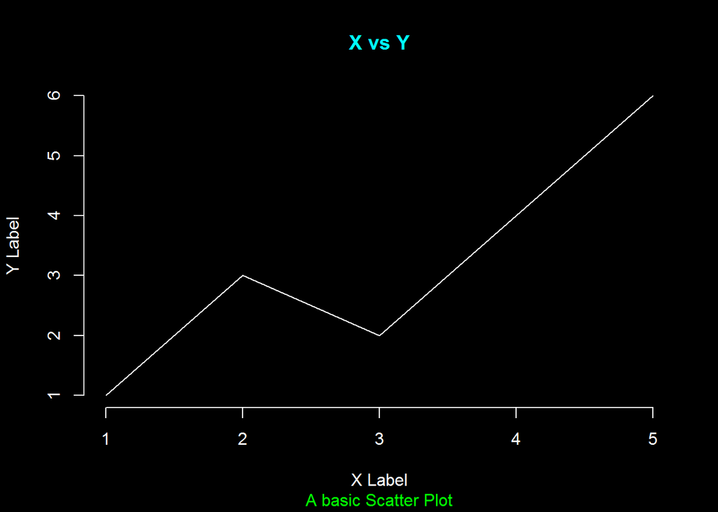

```r
par(bg='black', col.lab='white' ) #For the background and labels

plot(x,y, xlab='X Label', ylab='Y Label', type='l',col='white')
axis(1, col='white', col.axis = "white")#Note: col.axis is for the axis
axis(2, col='white', col.axis='white')
title(main='X vs Y', sub='A basic Scatter Plot',
        col.main='cyan', col.sub='green')
```

Suppose we want to make a scatterplot with the scattered points and the name of each point. For example, in the mtcars data set we can plot miles per gallon versus weight and name each point to according the name of the car. Let’s also add a regression line so we can see which cars get better or worse miles per gallon than expected based on the car’s weight.

```r
data("mtcars")
#Reset the grpahical paramters
dev.off()
```

```r
plot(mtcars$wt, mtcars$mpg, col='blue', pch=20,
     xlab='Weight', ylab='Miles per Gallon',
     main = 'Weight vs Miles per Gallon')
#Note: the cex makes the * larger or smaller
text(mtcars$wt, mtcars$mpg, labels = row.names(mtcars),
     cex=0.6, pos=2, col='darkgreen')
abline(lm(mpg~wt, data = mtcars))
#Note: pos=1 (under the dot), pos=2 (left of the dot)
```

[output not shown]

Now, we can see that based on this regression model the fiat for example gets more mpg than expected for its weight, whereas the camaro gets worse than expected for its weight.

When working with regression models, it is often useful to visualize the residuals by drawing a vertical line from the fitted values to the observed values. We can do this by using the lines function and drawing a line from the from the following two points: (x_obs, y_fitted) and (x_obs, y_obs)$, where “obs” and “fitted” refer to the observed and fitted values respectively. You could do this with a for loop but the more efficient way is to use the apply function.

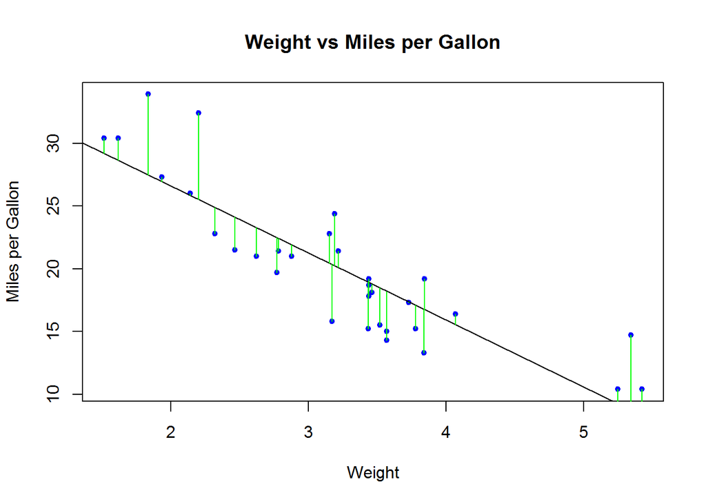

```r
#Fit a linear model
fit <- lm(mpg~wt, data = mtcars)
mat <- cbind(mtcars$wt, mtcars$wt, fit$fitted.values,   mtcars$mpg)
plot(mtcars$wt, mtcars$mpg, col='blue', pch=20,
     xlab='Weight', ylab='Miles per Gallon',
     main='Weight vs Miles per Gallon')
abline(fit)
apply(mat, 1, function(x) lines(x[1:2], x[3:4], col='green'))
```

Now, imagine we only want to do this for the Fiat 128.

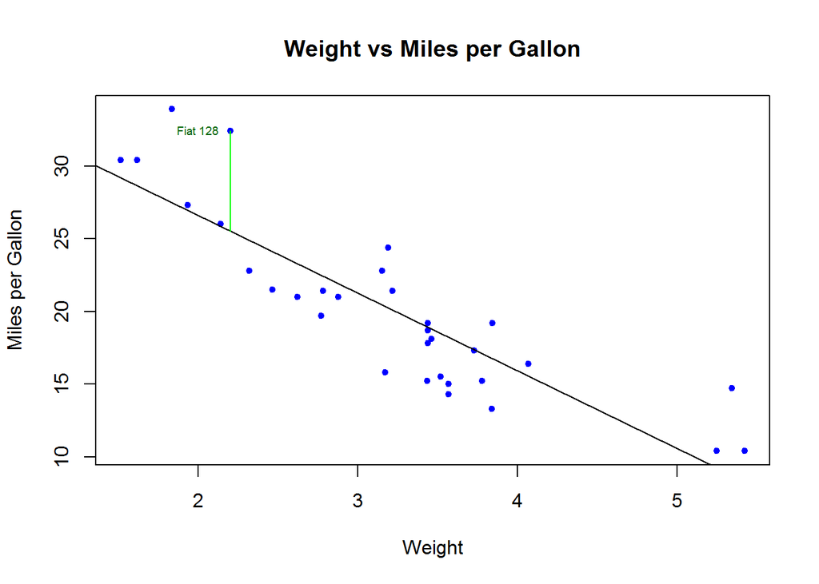

```r
#First let's find the index for the fiat
fiat <- mat[which(rownames(mat)=='Fiat 128'),]

plot(mtcars$wt, mtcars$mpg, col='blue', pch=20,
     xlab='Weight', ylab='Miles per Gallon',
     main='Weight vs Miles per Gallon')
abline(fit)
text(fiat[1], fiat[4], labels='Fiat 128',  cex=0.6, pos=2, col='darkgreen' )
lines(fiat[1:2], fiat[3:4], col='green')
```